# Using Linear Mixed Effects Models to Model Zebrafish LMR Data

Zachary Rowson

3/15/2022

## Introduction

LMEs allow us to model the deviation of individual Zebrafish tracks from the sample averaged parameters. How do we want to model these deviations?

## Visualize Data

Visualize data in Light to get an idea of which curve parameters vary for each fish. Look at a random sample of control fish.

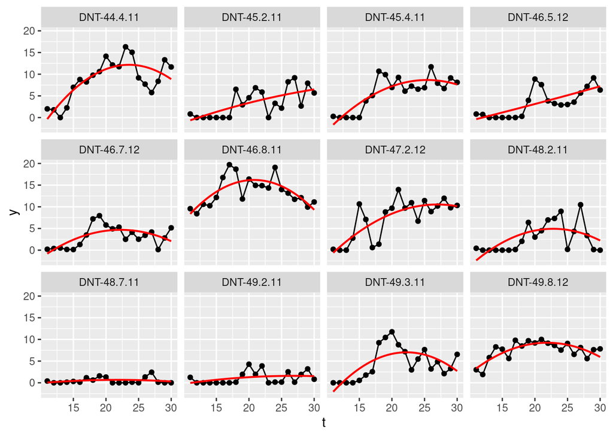

It appears that intercept parameter is fairly constant from one fish to another. What appears to vary most are the polynomial parameters for a poly2 fit. Maybe it’s fair to say slope varies most.

## Attempt to fit linear mixed effects models to each concentration group individually

### Control parameters for regression fitting.

```r
ctrl <- lmeControl(opt = "optim", niterEM = 10000, msTol = 1e-10, msVerbose = TRUE,
                   minAbsParApVar = 1e-10, maxIter = 1000, msMaxIter = 1000,
                   control = list(abstol=1e-10,reltol=1e-10,ndeps=1e-10))
```

### Fit to control data

```r
nest0 <- groupedData(y ~ conc|fishID, data =  dataL[conc==0],
                         order.groups = FALSE)
nest0$t <- nest0$t - min(nest0$t)
# Model lme
lmm0 <- lme(y ~ poly(t,degree=2,raw=TRUE),
            correlation = corAR1(, form = ~ t | fishID),
            random = ~ 0 + poly(t,degree=1,raw=TRUE) |fishID,
            method = "ML",
            control = ctrl,
            data = nest0)
lmm0$apVar
```

```
##                 reStruct.fishID    corStruct        lSigma
## reStruct.fishID    0.0095234468 -0.001314701 -0.0005326164
## corStruct         -0.0013147007  0.004389911  0.0014612162
## lSigma            -0.0005326164  0.001461216  0.0007394149
## attr(,"Pars")
## reStruct.fishID       corStruct          lSigma
##       -1.679140        1.468755        1.125539
## attr(,"natural")
## [1] TRUE
```

Model converges.

### Try with next concentration group, 0.004 uM.

```r
nest1 <- groupedData(y ~ conc|fishID, data =  dataL[conc==0.004],
                         order.groups = FALSE)
nest1$t <- nest1$t - min(nest1$t)
# Model lme
lmm1 <- lme(y ~ poly(t,degree=2,raw=TRUE),
            correlation = corAR1(, form = ~ t | fishID),
            random = ~ 0 + poly(t,degree=1,raw=TRUE) |fishID,
            method = "ML",
            control = ctrl,
            data = nest1)
lmm1$apVar
```

```
## [1] "Non-positive definite approximate variance-covariance"
```

Fit doesn’t work. It is likely that changing some convergence parameters would allow for a non-positive definite matrix, but do we really want to do this? Look at the current estimates for random effects variance of slope for 0.004uM.

```
## Linear mixed-effects model fit by maximum likelihood
##   Data: nest1
##   Log-likelihood: -796.4673
##   Fixed: y ~ poly(t, degree = 2, raw = TRUE)
##                      (Intercept) poly(t, degree = 2, raw = TRUE)1
##                       0.71310697                       0.80979818
## poly(t, degree = 2, raw = TRUE)2
##                      -0.03220133
##
## Random effects:
##  Formula: ~0 + poly(t, degree = 1, raw = TRUE) | fishID
##         poly(t, degree = 1, raw = TRUE) Residual
## StdDev:                    0.0001663806 4.119006
##
## Correlation Structure: AR(1)
##  Formula: ~t | fishID
##  Parameter estimate(s):
##       Phi
## 0.7189664
## Number of Observations: 320
## Number of Groups: 16
```

Standard Deviation is so small, maybe modelling the slope as random for this concentration group is inaccurate. Plot fish trackings for 0.004uM group to investigate this.

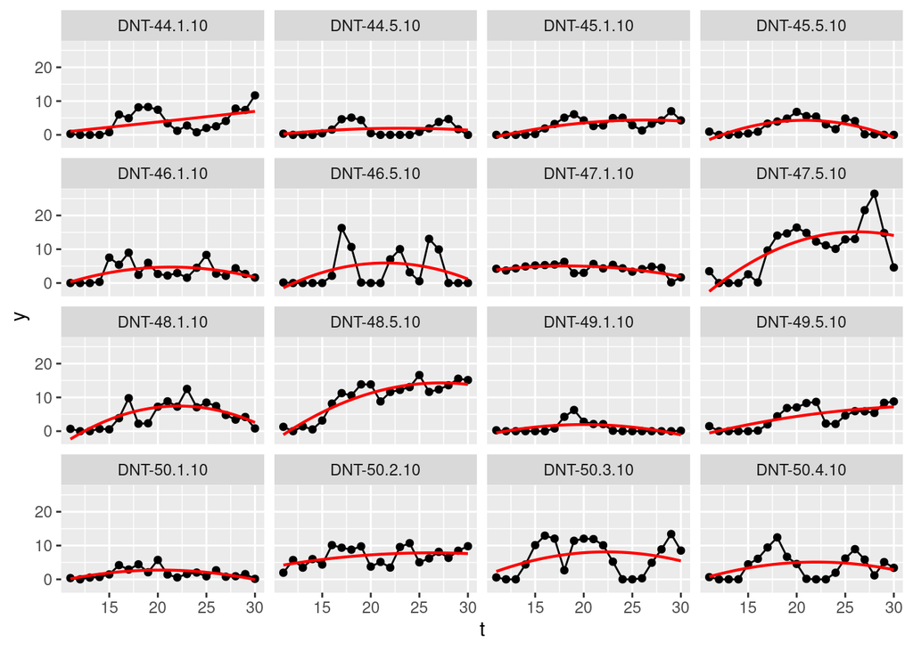